# Biostat 203B Homework 1

Due Jan 23, 2026 @ 11:59PM

Author

Rebekah Patel and 605566820

## Q1. Git/GitHub

**No handwritten homework reports are accepted for this course.** We work with Git and GitHub. Efficient and abundant use of Git, e.g., frequent and well-documented commits, is an important criterion for grading your homework.

1. Apply for the [Student Developer Pack](https://education.github.com/pack) at GitHub using your UCLA email. You’ll get GitHub Pro account for free (unlimited public and private repositories).
2. Create a **private** repository `biostat-203b-2026-winter` and add `Hua-Zhou` and TA team (`BowenZhang2001` for Lec 1; `Tomoki-Okuno` and `yucais` for Lec 82) as your collaborators with write permission.
3. Top directories of the repository should be `hw1`, `hw2`, … Maintain two branches `main` and `develop`. The `develop` branch will be your main playground, the place where you develop solution (code) to homework problems and write up report. The `main` branch will be your presentation area. Submit your homework files (Quarto file `qmd`, `html` file converted by Quarto, all code and extra data sets to reproduce results) in the `main` branch.
4. After each homework due date, course reader and instructor will check out your `main` branch for grading. Tag each of your homework submissions with tag names `hw1`, `hw2`, … Tagging time will be used as your submission time. That means if you tag your `hw1` submission after deadline, penalty points will be deducted for late submission.
5. After this course, you can make this repository public and use it to demonstrate your skill sets on job market.

**Solution:** I have followed the instructions and created the private repository `biostat-203b-2026-winter` on GitHub. I have added `Hua-Zhou` and the TA team as collaborators with write permission. The top directory of the repository is `hw1`. I have maintained two branches, `main` and `develop`, as specified. I will ensure to submit my homework files in the `main` branch and tag each submission appropriately after the due date.

## Q2. Data ethics training

This exercise (and later in this course) uses the [MIMIC-IV data v3.1](https://physionet.org/content/mimiciv/3.1/), a freely accessible critical care database developed by the MIT Lab for Computational Physiology. Follow the instructions at https://mimic.mit.edu/docs/gettingstarted/ to (1) complete the CITI `Data or Specimens Only Research` course and (2) obtain the PhysioNet credential for using the MIMIC-IV data. Display the verification links to your completion report and completion certificate here. **You must complete Q2 before working on the remaining questions.** (Hint: The CITI training takes a few hours and the PhysioNet credentialing takes a couple days; do not leave it to the last minute.)

**Solution:** I have completed the CITI `Data or Specimens Only Research` course and obtained the PhysioNet credential for using the MIMIC-IV data. Here are the verification links to my completion report and completion certificate: - [CITI Completion Report](https://www.citiprogram.org/verify/?k318cdeb0-be2d-4fdc-920c-e9b61a5cfcce-74519017) - [CITI Completion Certificate](https://www.citiprogram.org/verify/?w4805c31f-9c37-4302-8bdf-06ab3a70185c-74519017)

## Q3. Linux Shell Commands

1. Make the MIMIC-IV v3.1 data available at location `~/mimic`. The output of the `ls -l ~/mimic` command should be similar to the below (from my laptop).

```bash
# ln -s /Users/rebekahpatel/BIOSTAT203B/mimic-iv-3.1 ~/mimic
# content of mimic folder
ls -l ~/mimic/
```

```
total 56
-rw-r--r--@  1 rebekahpatel  staff  15199 Oct 10  2024 CHANGELOG.txt
-rw-r--r--@  1 rebekahpatel  staff   2518 Oct 10  2024 LICENSE.txt
-rw-r--r--@  1 rebekahpatel  staff   2884 Oct 11  2024 SHA256SUMS.txt
drwxr-xr-x@ 25 rebekahpatel  staff    800 Jan 19 13:06 hosp
drwxr-xr-x@ 13 rebekahpatel  staff    416 Jan 16 18:07 icu
-rw-r--r--@  1 rebekahpatel  staff    789 Dec 28  2024 index.html
```

Refer to the documentation https://physionet.org/content/mimiciv/3.1/ for details of data files. Do **not** put these data files into Git; they are big. Do **not** copy them into your directory. Do **not** decompress the gz data files. These create unnecessary big files and are not big-data-friendly practices. Read from the data folder `~/mimic` directly in following exercises.

**Solutions:** Created a symbolic link to the MIMIC-IV v3.1 data at location `~/mimic`. The output of the `ls -l ~/mimic` command shows the contents of the mimic folder as expected.

Use Bash commands to answer following questions.

2. Display the contents in the folders `hosp` and `icu` using Bash command `ls -l`. Why are these data files distributed as `.csv.gz` files instead of `.csv` (comma separated values) files? Read the page https://mimic.mit.edu/docs/iv/ to understand what’s in each folder.

```bash
ls -l ~/mimic/hosp

ls -l ~/mimic/icu
```

```
total 12306256
-rw-r--r--@ 1 rebekahpatel  staff    19928140 Jun 24  2024 admissions.csv.gz
-rw-r--r--@ 1 rebekahpatel  staff      427554 Apr 12  2024 d_hcpcs.csv.gz
-rw-r--r--@ 1 rebekahpatel  staff      876360 Apr 12  2024 d_icd_diagnoses.csv.gz
-rw-r--r--@ 1 rebekahpatel  staff      589186 Apr 12  2024 d_icd_procedures.csv.gz
-rw-r--r--@ 1 rebekahpatel  staff       13169 Oct  3  2024 d_labitems.csv.gz
-rw-r--r--@ 1 rebekahpatel  staff    33564802 Oct  3  2024 diagnoses_icd.csv.gz
-rw-r--r--@ 1 rebekahpatel  staff     9743908 Oct  3  2024 drgcodes.csv.gz
-rw-r--r--@ 1 rebekahpatel  staff   811305629 Apr 12  2024 emar.csv.gz
-rw-r--r--@ 1 rebekahpatel  staff   748158322 Apr 12  2024 emar_detail.csv.gz
-rw-r--r--@ 1 rebekahpatel  staff     2162335 Apr 12  2024 hcpcsevents.csv.gz
-rw-r--r--@ 1 rebekahpatel  staff        2907 Dec 28  2024 index.html
-rw-r--r--@ 1 rebekahpatel  staff  2592909134 Jan 19 13:02 labevents.csv.gz
-rw-r--r--@ 1 rebekahpatel  staff   117644075 Oct  3  2024 microbiologyevents.csv.gz
-rw-r--r--@ 1 rebekahpatel  staff    44069351 Oct  3  2024 omr.csv.gz
-rw-r--r--@ 1 rebekahpatel  staff     2835586 Apr 12  2024 patients.csv.gz
-rw-r--r--@ 1 rebekahpatel  staff   525708076 Apr 12  2024 pharmacy.csv.gz
-rw-r--r--@ 1 rebekahpatel  staff   666594177 Apr 12  2024 poe.csv.gz
-rw-r--r--@ 1 rebekahpatel  staff    55267894 Apr 12  2024 poe_detail.csv.gz
-rw-r--r--@ 1 rebekahpatel  staff   606298611 Apr 12  2024 prescriptions.csv.gz
-rw-r--r--@ 1 rebekahpatel  staff     7777324 Apr 12  2024 procedures_icd.csv.gz
-rw-r--r--@ 1 rebekahpatel  staff      127330 Apr 12  2024 provider.csv.gz
-rw-r--r--@ 1 rebekahpatel  staff     8569241 Apr 12  2024 services.csv.gz
-rw-r--r--@ 1 rebekahpatel  staff    46185771 Oct  3  2024 transfers.csv.gz
total 8535480
-rw-r--r--@ 1 rebekahpatel  staff       41566 Apr 12  2024 caregiver.csv.gz
-rw-r--r--@ 1 rebekahpatel  staff  3502392765 Apr 12  2024 chartevents.csv.gz
-rw-r--r--@ 1 rebekahpatel  staff       58741 Apr 12  2024 d_items.csv.gz
-rw-r--r--@ 1 rebekahpatel  staff    63481196 Apr 12  2024 datetimeevents.csv.gz
-rw-r--r--@ 1 rebekahpatel  staff    14686092 Feb 22  2025 icustays.csv
-rw-r--r--@ 1 rebekahpatel  staff     3342355 Oct  3  2024 icustays.csv.gz
-rw-r--r--@ 1 rebekahpatel  staff        1336 Dec 28  2024 index.html
-rw-r--r--@ 1 rebekahpatel  staff   311642048 Apr 12  2024 ingredientevents.csv.gz
-rw-r--r--@ 1 rebekahpatel  staff   401088206 Apr 12  2024 inputevents.csv.gz
-rw-r--r--@ 1 rebekahpatel  staff    49307639 Apr 12  2024 outputevents.csv.gz
-rw-r--r--@ 1 rebekahpatel  staff    24096834 Apr 12  2024 procedureevents.csv.gz
```

**Solution:** The data files are distributed as `.csv.gz` files instead of `.csv` files to save storage space and reduce download times. Compressed files take up less disk space and can be transferred more quickly over the internet. This is particularly important for large datasets like MIMIC-IV, which can be several gigabytes in size. By using gzip compression, users can efficiently download and store the data without needing excessive storage capacity.

3. Briefly describe what Bash commands `zcat`, `zless`, `zmore`, and `zgrep` do.

**Solution:** - zcat: This command uncompresses a list of files like .gz or its standard input and writes the uncompressed data on standard ouput. - zless: This command allows examination of compressed or plain text files one screenful on a terminal. If the files are compressed, the command uncompresses them itself. - zmore: This command also allows examination of compressed files and uncompresses them itself, one screenful at a time. - zgrep: This command searches expressions in compressed files, without needing to decompress them first.

4. (Looping in Bash) What’s the output of the following bash script?

```bash
for datafile in ~/mimic/hosp/{a,l,pa}*.gz
do
  ls -l $datafile
done
```

**Solution:** The output of the following bash script is the list of the compressed files in hosp directory that start with a, l, or pa and their details such as file size, permissions, owner, group, and modification date.

Display the number of lines in each data file using a similar loop. (Hint: combine linux commands `zcat <` and `wc -l`.)

```bash
for datafile in ~/mimic/hosp/{a,l,pa}*.gz
do
  echo $datafile; zcat < $datafile | wc -l
done
```

```
/Users/rebekahpatel/mimic/hosp/admissions.csv.gz
  546029
/Users/rebekahpatel/mimic/hosp/labevents.csv.gz
 158374765
/Users/rebekahpatel/mimic/hosp/patients.csv.gz
  364628
```

**Solution:** The following bash script loops through the hosp directory, finds the zipped files starting with a, l, or pa, prints their path name, unzips them using zcat, and counts the number of lines in each file using wc -l. The output will the be number of lines in each file.

5. Display the first few lines of `admissions.csv.gz`. How many rows are in this data file, excluding the header line? Each `hadm_id` identifies a hospitalization. How many hospitalizations are in this data file? How many unique patients (identified by `subject_id`) are in this data file? Do they match the number of patients listed in the `patients.csv.gz` file? (Hint: combine Linux commands `zcat <`, `head`/`tail`, `awk`, `sort`, `uniq`, `wc`, and so on.)

```bash
# display first 5 lines
zcat < ~/mimic/hosp/admissions.csv.gz | head -5
```

```
subject_id,hadm_id,admittime,dischtime,deathtime,admission_type,admit_provider_id,admission_location,discharge_location,insurance,language,marital_status,race,edregtime,edouttime,hospital_expire_flag
10000032,22595853,2180-05-06 22:23:00,2180-05-07 17:15:00,,URGENT,P49AFC,TRANSFER FROM HOSPITAL,HOME,Medicaid,English,WIDOWED,WHITE,2180-05-06 19:17:00,2180-05-06 23:30:00,0
10000032,22841357,2180-06-26 18:27:00,2180-06-27 18:49:00,,EW EMER.,P784FA,EMERGENCY ROOM,HOME,Medicaid,English,WIDOWED,WHITE,2180-06-26 15:54:00,2180-06-26 21:31:00,0
10000032,25742920,2180-08-05 23:44:00,2180-08-07 17:50:00,,EW EMER.,P19UTS,EMERGENCY ROOM,HOSPICE,Medicaid,English,WIDOWED,WHITE,2180-08-05 20:58:00,2180-08-06 01:44:00,0
10000032,29079034,2180-07-23 12:35:00,2180-07-25 17:55:00,,EW EMER.,P06OTX,EMERGENCY ROOM,HOME,Medicaid,English,WIDOWED,WHITE,2180-07-23 05:54:00,2180-07-23 14:00:00,0
```

**Solution:** This script uncompresses the file and displays the first 5 lines of the admissions file.

```bash
# how many rows excluding header line
zcat < ~/mimic/hosp/admissions.csv.gz | tail -n +2 | wc -l
```

```
  546028
```

**Solution:** This script counts the number of lines, aside of the header, in the admissions file. There are 546,028 lines in the admissions file, excluding the header.

```bash
# hospitalizations
zcat < ~/mimic/hosp/admissions.csv.gz | tail -n +2 |
  awk -F, '{print $2}' | sort | uniq | wc -l
```

```
  546028
```

**Solution:** This script finds the list of unique hospitalizations and counts how many there are. There are 546,028 hospitalizations in the admissions file, the same as the number of rows, which means all hospitalizations are unique.

```bash
#patients
zcat < ~/mimic/hosp/admissions.csv.gz | tail -n +2 |
  awk -F, '{print $1}' | sort | uniq | wc -l
```

```
  223452
```

**Solution:** This script finds the list of unique patients in the admissions file and counts how many there are. There are 223,452 unique patients in the admissions file. It searches all rows except for the header, in the patients column, sorts them, finds the unique ones, and counts them.

```bash
#patients in patients.csv.gz
zcat < ~/mimic/hosp/patients.csv.gz | tail -n +2 |
  awk -F, '{print $1}' | sort | uniq | wc -l
```

```
  364627
```

**Solution:** This script finds the list of unique patients in the patients file and counts how many there are. There are 364,627 unique patients in the patients file. The number of unique patients in the admissions file (223,452) does not match the number of unique patients in the patients file (364,627).

6. What are the possible values taken by each of the variable `admission_type`, `admission_location`, `insurance`, and `ethnicity`? Also report the count for each unique value of these variables in decreasing order. (Hint: combine Linux commands `zcat`, `head`/`tail`, `awk`, `uniq -c`, `wc`, `sort`, and so on; skip the header line.)

```bash
# admission_type => 6
zcat < ~/mimic/hosp/admissions.csv.gz | tail -n +2 |
  awk -F, '{print $6}'| sort | uniq -c | sort -nr
```

```
177459 EW EMER.
119456 EU OBSERVATION
84437 OBSERVATION ADMIT
54929 URGENT
42898 SURGICAL SAME DAY ADMISSION
24551 DIRECT OBSERVATION
21973 DIRECT EMER.
13130 ELECTIVE
7195 AMBULATORY OBSERVATION
```

```bash
# admission_location, 8
zcat < ~/mimic/hosp/admissions.csv.gz | tail -n +2 |
  awk -F, '{print $8}' | sort | uniq -c | sort -nr
```

```
244179 EMERGENCY ROOM
163228 PHYSICIAN REFERRAL
56227 TRANSFER FROM HOSPITAL
42365 WALK-IN/SELF REFERRAL
12965 CLINIC REFERRAL
8518 PROCEDURE SITE
6317 TRANSFER FROM SKILLED NURSING FACILITY
5837 INTERNAL TRANSFER TO OR FROM PSYCH
5734 PACU
 402 INFORMATION NOT AVAILABLE
 255 AMBULATORY SURGERY TRANSFER
   1
```

```bash
# insurance, 11
zcat < ~/mimic/hosp/admissions.csv.gz | tail -n +2 |
  awk -F, '{print $10}' | sort | uniq -c | sort -nr
```

```
244576 Medicare
173399 Private
104229 Medicaid
14006 Other
9355
 463 No charge
```

```bash
# ethnicity, 14
zcat < ~/mimic/hosp/admissions.csv.gz | tail -n +2 |
  awk -F, '{print $13}' | sort | uniq -c | sort -nr
```

```
336538 WHITE
75482 BLACK/AFRICAN AMERICAN
19788 OTHER
13972 WHITE - OTHER EUROPEAN
13870 UNKNOWN
10903 HISPANIC/LATINO - PUERTO RICAN
8287 HISPANIC OR LATINO
7809 ASIAN
7644 ASIAN - CHINESE
6597 WHITE - RUSSIAN
6205 BLACK/CAPE VERDEAN
6070 HISPANIC/LATINO - DOMINICAN
3875 BLACK/CARIBBEAN ISLAND
3495 BLACK/AFRICAN
3478 UNABLE TO OBTAIN
```

[output cut: 18 more lines]

**Solution:** Each script searches the admissions file, excluding header, for the unique values of the specific column and counts how many times they show up. Each script uses the same commands, but changes the searched column. The script sorts each column, counts each distinct value, and sorts the counts in decreasing order.

7. The `icusays.csv.gz` file contains all the ICU stays during the study period. How many ICU stays, identified by `stay_id`, are in this data file? How many unique patients, identified by `subject_id`, are in this data file?

```bash
zcat < ~/mimic/icu/icustays.csv.gz | tail -n +2 |
  awk -F, '{print $3}' | sort | uniq | wc -l

zcat < ~/mimic/icu/icustays.csv.gz | wc -l

zcat < ~/mimic/icu/icustays.csv.gz | tail -n +2 |
  awk -F, '{print $1}' | sort | uniq | wc -l
```

```
   94458
   94459
   65366
```

**Solution:** The number of ICU stays in the file is 94,458, which is also the same number of rows in the file, excluding the header. There are 65,366 unique patients in the data file. The first command searches the stay_id column and counts the distinct ids. The second command counts the number of rows because I wanted to know whether the number of unique icu stays is the same as the number of rows excluding the header. The third command searches the subject_id column and counts the unique values.

8. *To compress, or not to compress. That’s the question.* Let’s focus on the big data file `labevents.csv.gz`. Compare compressed gz file size to the uncompressed file size. Compare the run times of `zcat < ~/mimic/labevents.csv.gz | wc -l` versus `wc -l labevents.csv`. Discuss the trade off between storage and speed for big data files. (Hint: `gzip -dk < FILENAME.gz > ./FILENAME`. Remember to delete the large `labevents.csv` file after the exercise.)

```bash
gzip -dk < ~/mimic/hosp/labevents.csv.gz > ~/mimic/labevents.csv
```

```bash
time zcat < ~/mimic/hosp/labevents.csv.gz | wc -l
time wc -l ~/mimic/labevents.csv
```

```
 158374765

real    0m34.023s
user    0m57.538s
sys 0m5.618s
 158374765 /Users/rebekahpatel/mimic/labevents.csv

real    0m39.326s
user    0m31.487s
sys 0m6.128s
```

```bash
ls -l ~/mimic/hosp/labevents.csv.gz
ls -l ~/mimic/labevents.csv
```

```
-rw-r--r--@ 1 rebekahpatel  staff  2592909134 Jan 19 13:02 /Users/rebekahpatel/mimic/hosp/labevents.csv.gz
-rw-r--r--@ 1 rebekahpatel  staff  18402851720 Jan 23 11:22 /Users/rebekahpatel/mimic/labevents.csv
```

```bash
rm ~/mimic/labevents.csv
```

## Q4. Who’s popular in Pride and Prejudice

1. You and your friend just have finished reading *Pride and Prejudice* by Jane Austen. Among the four main characters in the book, Elizabeth, Jane, Lydia, and Darcy, your friend thinks that Darcy was the most mentioned. You, however, are certain it was Elizabeth. Obtain the full text of the novel from http://www.gutenberg.org/cache/epub/42671/pg42671.txt and save to your local folder.

```bash
wget -nc http://www.gutenberg.org/cache/epub/42671/pg42671.txt
```

Explain what `wget -nc` does. Do **not** put this text file `pg42671.txt` in Git. Complete the following loop to tabulate the number of times each of the four characters is mentioned using Linux commands.

```bash
wget -nc http://www.gutenberg.org/cache/epub/42671/pg42671.txt
for char in Elizabeth Jane Lydia Darcy
do
  echo $char:
  grep -woc $char pg42671.txt
done
```

[output not shown]

2. What’s the difference between the following two commands?

```bash
echo 'hello, world' > test1.txt
```

and

```bash
echo 'hello, world' >> test2.txt
```

```bash
cat test1.txt
cat test2.txt
```

```
hello, world
hello, world
```

**Solution:** The first command uses >, which overwrites test1.txt and puts in the output of echo ‘hello, world’. The second command uses >> which appends the output of echo ‘hello, world’ to test2.txt.

3. Using your favorite text editor (e.g., `vi`), type the following and save the file as `middle.sh`:

```bash
#!/bin/sh
# Select lines from the middle of a file.
# Usage: bash middle.sh filename end_line num_lines
head -n "$2" "$1" | tail -n "$3"
```

Using `chmod` to make the file executable by the owner, and run

```bash
./middle.sh pg42671.txt 20 5
```

[output not shown]

Explain the output. Explain the meaning of `"$1"`, `"$2"`, and `"$3"` in this shell script. Why do we need the first line of the shell script?

**Solution:** `"$1"`, `"$2"`, and `"$3"` are the arguments that follow after calling the shell script. `"$1"`is pg42671.txt, the file that contains *Pride and Prejudice*. `"$2"` is 20 and `"$3"` is 5. The shell script takes the first 20 lines of the text file and inputs it into the pipe to get the last 5 lines of the first 20. The lines 16, 17, 18, 19, and 20 are displayed from the text file. The first line of the shell script #!/bin/sh is a declaration that tells the operator which interpreter to use to execute the commands in the script.

## Q5. More fun with Linux

Try following commands in Bash and interpret the results: `cal`, `cal 2026`, `cal 9 1752` (anything unusual?), `date`, `hostname`, `arch`, `uname -a`, `uptime`, `who am i`, `who`, `w`, `id`, `last | head`, `echo {con,pre}{sent,fer}{s,ed}`, `time sleep 5`, `history | tail`.

```bash
cal
cal 2026
cal 9 1752
```

```
    January 2026
Su Mo Tu We Th Fr Sa
             1  2  3
 4  5  6  7  8  9 10
11 12 13 14 15 16 17
18 19 20 21 22 23 24
25 26 27 28 29 30 31

                            2026
      January               February               March
Su Mo Tu We Th Fr Sa  Su Mo Tu We Th Fr Sa  Su Mo Tu We Th Fr Sa
             1  2  3   1  2  3  4  5  6  7   1  2  3  4  5  6  7
 4  5  6  7  8  9 10   8  9 10 11 12 13 14   8  9 10 11 12 13 14
11 12 13 14 15 16 17  15 16 17 18 19 20 21  15 16 17 18 19 20 21
18 19 20 21 22 23 24  22 23 24 25 26 27 28  22 23 24 25 26 27 28
25 26 27 28 29 30 31                        29 30 31


       April                  May                   June
Su Mo Tu We Th Fr Sa  Su Mo Tu We Th Fr Sa  Su Mo Tu We Th Fr Sa
          1  2  3  4                  1  2      1  2  3  4  5  6
 5  6  7  8  9 10 11   3  4  5  6  7  8  9   7  8  9 10 11 12 13
12 13 14 15 16 17 18  10 11 12 13 14 15 16  14 15 16 17 18 19 20
19 20 21 22 23 24 25  17 18 19 20 21 22 23  21 22 23 24 25 26 27
26 27 28 29 30        24 25 26 27 28 29 30  28 29 30
                      31

        July                 August              September
Su Mo Tu We Th Fr Sa  Su Mo Tu We Th Fr Sa  Su Mo Tu We Th Fr Sa
          1  2  3  4                     1         1  2  3  4  5
 5  6  7  8  9 10 11   2  3  4  5  6  7  8   6  7  8  9 10 11 12
12 13 14 15 16 17 18   9 10 11 12 13 14 15  13 14 15 16 17 18 19
19 20 21 22 23 24 25  16 17 18 19 20 21 22  20 21 22 23 24 25 26
26 27 28 29 30 31     23 24 25 26 27 28 29  27 28 29 30
                      30 31

      October               November              December
Su Mo Tu We Th Fr Sa  Su Mo Tu We Th Fr Sa  Su Mo Tu We Th Fr Sa
             1  2  3   1  2  3  4  5  6  7         1  2  3  4  5
 4  5  6  7  8  9 10   8  9 10 11 12 13 14   6  7  8  9 10 11 12
11 12 13 14 15 16 17  15 16 17 18 19 20 21  13 14 15 16 17 18 19
18 19 20 21 22 23 24  22 23 24 25 26 27 28  20 21 22 23 24 25 26
25 26 27 28 29 30 31  29 30                 27 28 29 30 31

   September 1752
Su Mo Tu We Th Fr Sa
       1  2 14 15 16
17 18 19 20 21 22 23
24 25 26 27 28 29 30
```

**Solution**: - cal: displays the calendar month of the current year and month. - cal 2026: displays all the calendar months of 2026 - cal 9 1752: displays the calendar month of 9 in 1752. However, there are missing days from 3 to 13 for some reason.

```bash
date
hostname
arch
```

```
Fri Jan 23 11:23:56 PST 2026
Rebekahs-MacBook-Air.local
i386
```

**Solution:** - date: displays the current day, time and timezone of the user, and year - hostname: user’s hostname on Linux - arch: user’s computer architecture system

```bash
uname -a
uptime
who am i
who
w
id
last | head
```

```
Darwin Rebekahs-MacBook-Air.local 23.6.0 Darwin Kernel Version 23.6.0: Thu Apr 24 20:26:36 PDT 2025; root:xnu-10063.141.1.705.2~1/RELEASE_X86_64 x86_64
11:23  up 23:14, 1 user, load averages: 2.34 2.50 2.80
rebekahpatel                  Jan 23 11:23
rebekahpatel     console      Jan 22 12:10
11:23  up 23:14, 1 user, load averages: 2.34 2.50 2.80
USER       TTY      FROM    LOGIN@  IDLE WHAT
rebekahpat console  -      Thu12   23:13 -
uid=501(rebekahpatel) gid=20(staff) groups=20(staff),12(everyone),61(localaccounts),79(_appserverusr),80(admin),81(_appserveradm),98(_lpadmin),701(com.apple.sharepoint.group.1),33(_appstore),100(_lpoperator),204(_developer),250(_analyticsusers),395(com.apple.access_ftp),398(com.apple.access_screensh…
rebekahpatel console                         Thu Jan 22 12:10   still logged in
reboot time                                Thu Jan 22 12:09
rebekahpatel console                         Tue Jan 20 12:04 - crash (2+00:05)
reboot time                                Tue Jan 20 12:04
shutdown time                              Tue Jan 20 12:03
rebekahpatel ttys000                         Fri Jan 16 20:05 - 20:05  (00:00)
rebekahpatel ttys000                         Sat Jan 10 19:23 - 19:23  (00:00)
rebekahpatel ttys000                         Sat Jan 10 19:18 - 19:18  (00:00)
rebekahpatel ttys000                         Sat Jan 10 19:17 - 19:17  (00:00)
rebekahpatel console                         Fri Jan  9 18:18 - 12:03 (10+17:45)
```

**Solution:** - uname -a: displays the operating system implementation with -a flag allowing all details to be displayed - uptime: shows how long the system has been running, current ime, length of time system has been up, the numbers of users, and the load average of the system over the last 1, 5, and 15 minutes - who am i: displays information about the current logged in user, including login name, tty name, date and time of login, which is the current time - who: displays default information of the current logged in user - w: print a summary of the current activity of the system, including what the user is doing. - id: prints the users identity number, me and the guest user - last | head: shows the last logged in users, and head only shows the first 10 lines of the output

## Q6. Book

1. Git clone the repository https://github.com/christophergandrud/Rep-Res-Book for the book *Reproducible Research with R and RStudio* to your local machine. Do **not** put this repository within your homework repository `biostat-203b-2026-winter`.
2. Open the project by clicking `rep-res-3rd-edition.Rproj` and compile the book by clicking `Build Book` in the `Build` panel of RStudio. (Hint: I was able to build `git_book` and `epub_book` directly. For `pdf_book`, I needed to add a line `\usepackage{hyperref}` to the file `Rep-Res-Book/rep-res-3rd-edition/latex/preabmle.tex`.)

The point of this exercise is (1) to obtain the book for free and (2) to see an example how a complicated project such as a book can be organized in a reproducible way. Use `sudo apt install PKGNAME` to install required Ubuntu packages and `tlmgr install PKGNAME` to install missing TexLive packages.

For grading purpose, include a screenshot of Section 4.1.5 of the book here.

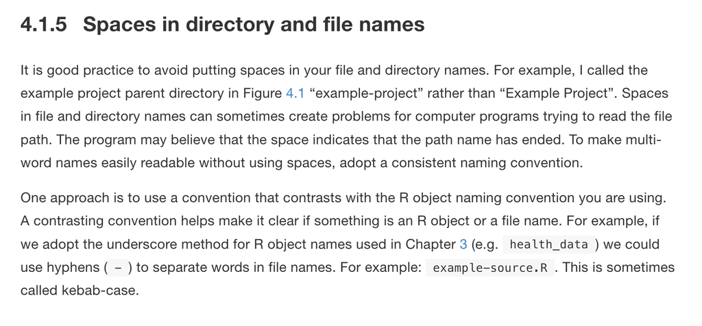

## Q7. AI assistant

Which AI assistants (e.g., GitHub Copilot) do you use when working on this assignment? Which AI model (e.g., GPT-5 mini, GPT-5, Claude Sonnet 4.5) does the AI assistant use? How do you use them? Do you think they help improve your productivity?

Give 5 instances where AI model gave incorrect or misleading answers. You can use screenshots or copy-paste the Q&A.

**Solution:** I used two AI assistants working on this assignment. GitHub Copilot through RStudio and Claude Sonnet 4.5. GitHub Copilot helped me with writing bash scripts and commands, while Claude Sonnet 4.5 helped me with debugging my code when I received error messages. Both AI assistants helped improve my productivity by providing quick solutions and suggestions, allowing me to focus on understanding the concepts rather than getting stuck on specific coding issues.

Here are 5 instances where the AI model gave incorrect or misleading answers: 1. Copilot suggested an incorrect link for my Citi certificate.

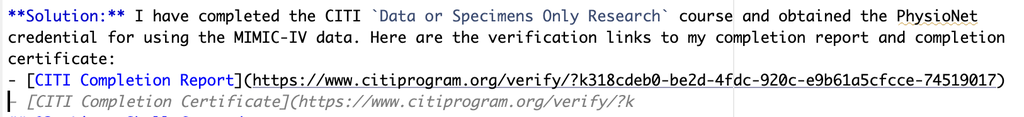

2. Copilot suggested using an incorrect awk command to count unique patients.

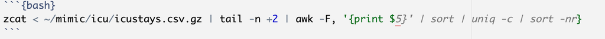

3. Claude Sonnet 4.5 provided an incorrect solution for gzip decompression which caused additional errors.

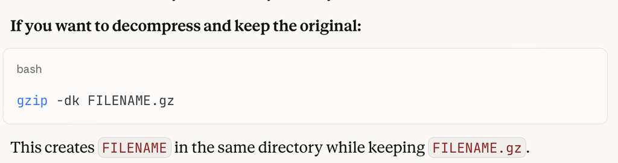

4. Copilot suggested an incorrect description of my usage of Claude Sonnet 4.5.1.

[figure not shown]

5. Copilot suggested an incorrect image file name for a screenshot in this section.

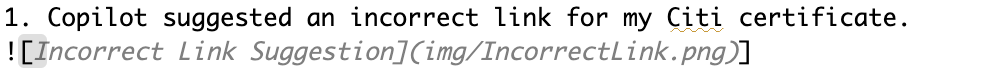